# ¶ “RENDIMIENTO Y CUALIDADES FÍSICAS DE CADA JUGADOR DE LA LIGA SANTANDER DE ESPAÑA TEMPORADA 2022-2023” ¶

## **ÍNDICE:**

##### **1. Introducción**

##### *Relevancia*

##### *Objetivo*

##### *Contexto*

##### **2. Planificación**

##### **3. Datos**

##### *Recolección de datos*

##### *Población, muestra y muestreo*

##### *Variables*

##### *Limpieza de base de datos*

##### **4. Análisis Descriptivo**

```r
# En caso de no tener instalado las librerías que se utilizará
#install.packages("ggplot2")
#install.packages("ggthemes")
#install.packages("descr")
#install.packages("modeest")
#install.packages("stringi")
#install.packages("stringr")
```

### INTRODUCCIÓN

#### RELEVANCIA:

El fútbol es importante en todo el mundo porque tiene muchos seguidores cabe mencionar que la industria del fútbol es muy influyente en la actualidad “La liga santander de España” es una de las más reconocidas y competitivas a nivel profesional en Europa. Por ello, nosotros buscamos resaltar a sus jugadores quienes demuestran su compromiso con el equipo, sus jugadas más destacadas y sus mejores goles en todo el mundo, y asi se puede incentivar a los niños y fomentar este deporte sano donde tienen a estos jugadores como un modelo a seguir. Asimismo, mencionar que el deporte es una actividad saludable en líneas generales el fútbol tiene como objetivos entretener a la afición e incentivar las buenas prácticas deportivas. Además, nosotros buscamos saber si la edad de un jugador es un factor influyente en su rendimiento tanto para él y para el equipo.

#### OBJETIVO GENERAL:

- Análisis e interpretación de una base de datos de deporte con el objetivo de ver los factores que influyen en la liga Santánder de España para un adecuado desempeño físico, mental y el rendimiento de cada jugador en el terreno de juego.
- Observar las ventajas y desventajas que puede proporcionar cada jugador a su equipo durante la jornada de la liga Santánder de España.

##### OBJETIVO ESPECÍFICO:

- Determinar si la edad es un factor influyente en el rendimiento del jugador profesional, si este afecta en la cantidad de disparos al arco que realiza o en el aporte al equipo de fútbol.
- Identificar al jugador con el mejor rendimiento físico tomando en cuenta las variables numéricas, como minutos jugados en cada partido y sus apariciones en cada posición.
- Estimar el mejor jugador de la temporada tomando en cuenta las variables cuantitativas como los partidos jugados, porcentaje de acierto en los pases, duelos aéreos ganados y ver la posición en donde es más eficiente cada jugador.
- Analizar qué jugador es el que menos infracciones comete a lo largo de la temporada de la liga Santander, la cantidad de tarjetas amarillas, determinando a qué equipo pertenece.

#### CONTEXTO:

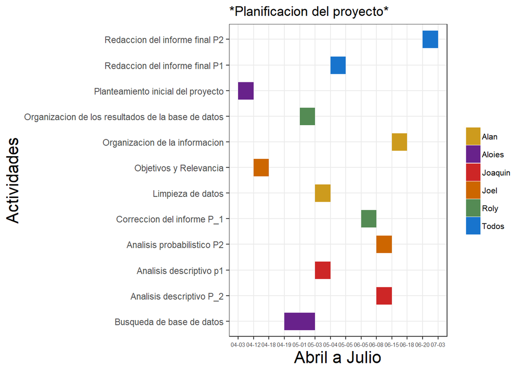

```r
data <- data.frame(Integrantes = c('Planteamiento inicial del proyecto','Objetivos y Relevancia','  Busqueda de base de datos','Organizacion de los resultados de la base de datos','Limpieza de datos','Analisis descriptivo p1', 'Redaccion del informe final P1','Correccion del informe P_1', 'Analisis descriptivo P_2','Analisis probabilistico P2', 'Organizacion de la informacion', 'Redaccion del informe final P2'))
inicio = c('04-03', '04-12', '04-19', '05-01', '05-03','05-03', '05-04','06-05','06-08','06-08','06-15','06-20')
fin = c('04-12', '04-18', '05-03','05-03','05-04','05-04', '05-05','06-08','06-15','06-15','06-18','07-03')
A= c('Aloies','Joel','Aloies','Roly','Alan', 'Joaquin','Todos','Roly','Joaquin','Joel','Alan','Todos')

ggplot(data, aes(x=inicio, xend=fin, y=Integrantes, yend=Integrantes, color=A)) +
  theme_bw()+  geom_segment(size=8) + labs(title='*Planificacion del proyecto*', x='Abril a Julio', y='Actividades') + scale_colour_manual(values = c('goldenrod3', 'darkorchid4', 'firebrick3','darkorange3','palegreen4','dodgerblue3','red','blue','lightgreen','brown','grey','lightyellow','royalblue')) +
  theme(axis.title = element_text(size=16))+
  theme(axis.text.x = element_text(size=5.5))+
  theme(legend.text = element_text(size=8))+
  theme(legend.title = element_text(size=0))
```

### DATOS

#### INSTRUMENTO DE RECOLECCIÓN:

Fuente primaria, se obtuvo la base de datos de la pagina web:

[BaseDeDatos(https://www.kaggle.com/datasets/rayhan32/la-liga-player-status-season-2022-2023)]

#### Población:

- Todos los registros de los rendimientos de cada jugador de la Liga Santander de España primera división en la temporada 2022-2023.

#### Muestra:

- Registros de todos lo jugadores que tengan todos sus datos completos en la base de datos.

#### Muestreo:

- Base de datos recolectada de una página conocida KAGGLE, donde se eligió el área de deporte de manera aleatoria.

#### Variables

##### **Variables Categóricas:**

- *Nombre del Jugador* | **NOMBRE**
- *Equipo del jugador* | **EQUIPO**
- *Posición de juego en el campo* | **POSICIÓN**

##### **Variables Numéricas:**

- *Edad del jugador* | **EDAD**
- *Aparición o partido en el campo* | **PARTIDO**
- *Asistencia* | **ASISTENCIA**
- *Minutos jugados* | **MINUTOS**
- *Total de goles* | **GOLES**
- *Cantidad de tarjeta amarilla* | **AMARILLA**
- *Cantidad de tarjeta roja* | **ROJA**
- *Cantidad de disparos al arco* | **DISPAROS**
- *Porcentaje de aciertos en los pases* | **PASES_A**
- *Duelos aéreos ganados por partido* | **AEREOS_G**
- *Hombre del Partido* | **MVP**

#### Limpieza de base de datos

##### Base de datos inicial

```r
liga = read.csv("lalaiga 2 all player final - lalaiga 2 all player.csv",fileEncoding = "utf8")
```

```r
liga
```

| Player.Name | Team.name | Age | Position | App | MinP | Goals | Assist | YC | RC | SPG | PS. | AW | MOTM | Rating |
| --- | --- | --- | --- | --- | --- | --- | --- | --- | --- | --- | --- | --- | --- | --- |
| Robert Lewandowski | Barcelona | 34 | FW | 20(1) | 1682 | 15 | 5 | NA | 1 | 3.8 | 79 | 1.6 | 7 | 7.53 |
| Karim Benzema | Real Madrid | 35 | FW | 15 | 1306 | 11 | 3 | 1 | NA | 4.7 | 87 | 0.7 | 4 | 7.45 |
| Antoine Griezmann | Atletico | 31 | AM(CLR) FW | 18(7) | 1693 | 8 | 8 | NA | NA | 2.6 | 81.5 | 0.8 | 5 | 7.45 |
| Vinícius Júnior | Real Madrid | 22 | AM(L) FW | 24 | 2122 | 8 | 4 | 8 | NA | 2.5 | 82.3 | NA | 4 | 7.38 |
| Pedri | Barcelona | 20 | AM(CL) | 18(3) | 1634 | 6 | NA | 2 | NA | 0.8 | 88.5 | NA | 3 | 7.28 |
| Federico Valverde | Real Madrid | 24 | M(CLR) | 22() | 1960 | 7 | 2 | 2 | NA | 2.1 | 88.2 | 0.9 | 4 | 7.26 |
| Mikel Merino | Real Sociedad | 26 | M(C) | 18(3) | 1607 | 1 | 7 | 5 | 1 | 1.5 | 76.8 | 3.5 | 5 | 7.23 |
| Joselu | Espanyol | 32 | FW | 21(23) | 1909 | 12 | 2 | 3 | NA | 2.5 | 61.6 | 5.6 | 4 | 7.22 |
| Rodrygo | Real Madrid | 22 | AM(CLR) FW | 16(6) | 1546 | 4 | 5 | 2 | NA | 2.9 | 89.9 | 0.5 | 2 | 7.20 |
| Memphis Depay | Barcelona | 29 | AM(CL) FW | 2 | 116 | 1 | NA | NA | NA | 3.0 | 83.9 | 0.5 | NA | 7.20 |

[output cut: 532 more lines]

##### Buscando las variables con mayores datos faltantes

```r
sum(is.na(liga$Goals))
```

```
## [1] 326
```

```r
sum(is.na(liga$RC))
```

```
## [1] 450
```

```r
sum(is.na(liga$Assist))
```

```
## [1] 336
```

```r
sum(is.na(liga$MOTM))
```

```
## [1] 391
```

##### Renombrando los nombres de las variables y almacenandolo en una nueva base

```r
Laliga_limpia= rename(liga,NOMBRE=Player.Name,EQUIPO=Team.name,EDAD=Age,POSICION=Position,PARTIDO=App,MINUTOS=MinP,GOLES=Goals,ASISTENCIA=Assist,AMARILLA=YC,ROJA=RC,DISPAROS=SPG,PASES_A=PS.,AEREOS_G=AW,MVP=MOTM,CLASIFICACION=Rating)
```

##### Eliminamos las variables con mayor cantidad de NA

```r
Laliga_limpia$GOLES <- NULL
Laliga_limpia$ROJA <- NULL
Laliga_limpia$MVP <- NULL
Laliga_limpia$ASISTENCIA <- NULL
```

##### Eliminamos las observaciones con NA y almacenando la base de datos inicial en otra nueva

```r
LALIGA = na.omit(Laliga_limpia)
```

##### Agregando tres nuevas variables de todos los jugadores que solo sean Delanteros, Defensas y Mediocampistas en general con los datos de TRUE o FALSE

###### DEFENSA

```r
LALIGA$DEFENSA <- FALSE
LALIGA$DEFENSA[grep("D", LALIGA$POSICION)] <- TRUE
LALIGA$DEFENSA[grep("DMC", LALIGA$POSICION)] <- TRUE
```

###### MEDIO

```r
LALIGA$MEDIO <- FALSE
LALIGA$MEDIO[grep("M", LALIGA$POSICION)] <- TRUE
LALIGA$MEDIO[grep("DMC", LALIGA$POSICION)] <- FALSE
```

###### DELANTERO

```r
LALIGA$DELANTERO <- FALSE
LALIGA$DELANTERO[grep("F", LALIGA$POSICION)] <- TRUE
```

##### Creamos tres variables adicionales para conocer los defensas izquierdos, derechos y medios.

##### Agregando una nueva variable DEFENSAD de todos los jugadores que son Defensas Derechos y asignadoles TRUE si en su posición aparece D(R).

```r
LALIGA$DEFENSAD = LALIGA$POSICION
LALIGA$DEFENSAD[grep("D\\(.*R.*\\)", LALIGA$DEFENSAD)] <- TRUE
```

###### Agregando una nueva variable DEFENSAI de todos los jugadores que son Defensas Izquierdos y asignadoles TRUE si en su posición aparece D(L)

```r
LALIGA$DEFENSAI = LALIGA$POSICION
LALIGA$DEFENSAI[grep("D\\(.*L.*\\)", LALIGA$DEFENSAI)] <- TRUE
```

###### Agregando una nueva variable DEFENSAC de todos los jugadores que son Defensas Centrales y asignadoles TRUE si en su posición aparece D(C), DMC o Defender

```r
LALIGA$DEFENSAC = LALIGA$POSICION
LALIGA$DEFENSAC[grep("D\\(.*C.*\\)", LALIGA$DEFENSAC)] <- TRUE
LALIGA$DEFENSAC[grep("Defender", LALIGA$DEFENSAC)] <- TRUE
LALIGA$DEFENSAC[grep("DMC", LALIGA$DEFENSAC)] <- TRUE
```

##### MEDIO

###### Agregando una nueva variable MEDIOI de todos los jugadores que son Medios Izquierdos y asignadoles TRUE si en su posición aparece M(L)

```r
LALIGA$MEDIOI = LALIGA$POSICION
LALIGA$MEDIOI[grep("M\\(.*L.*\\)", LALIGA$MEDIOI)] <- TRUE
```

###### Agregando una nueva variable MEDIOD de todos los jugadores que son Medios Derechos y asignadoles TRUE si en su posición aparece M(R)

```r
LALIGA$MEDIOD = LALIGA$POSICION
LALIGA$MEDIOD[grep("M\\(.*R.*\\)", LALIGA$MEDIOD)] <- TRUE
```

###### Agregando una nueva variable MEDIOC de todos los jugadores que son Medios Centrales y asignadoles TRUE si en su posición aparece M(C), Miedfielder

```r
LALIGA$MEDIOC = LALIGA$POSICION
LALIGA$MEDIOC[grep("M\\(.*C.*\\)", LALIGA$MEDIOC)] <- TRUE
LALIGA$MEDIOC[grep("Midfielder", LALIGA$MEDIOC)] <- TRUE
```

###### Una vez asignado y creado las variables adicionales procedemos a asignar con FALSE aquellas que no cumplen con las condiciones dadas anteriormente

###### Verificando en la variable DEFENSAD aquellos datos que no sean TRUE, y se le asigna FALSE

```r
LALIGA %>% mutate(DEFENSAD =

         ifelse(DEFENSAD!=TRUE,FALSE,
         DEFENSAD))-> LALIGA
```

###### Verificando en la variable DEFENSAI aquellos datos que no sean TRUE, y se le asigna FALSE

```r
LALIGA %>% mutate(DEFENSAI =

         ifelse(DEFENSAI!=TRUE,FALSE,
         DEFENSAI))-> LALIGA
```

###### Verificando en la variable DEFENSAC aquellos datos que no sean TRUE, y se le asigna FALSE

```r
LALIGA %>% mutate(DEFENSAC =

         ifelse(DEFENSAC!=TRUE,FALSE,
         DEFENSAC))-> LALIGA
```

###### Verificando en la variable MEDIOI aquellos datos que no sean TRUE, y se le asigna FALSE

```r
LALIGA %>% mutate(MEDIOI =

         ifelse(MEDIOI!=TRUE,FALSE,
         MEDIOI))-> LALIGA
```

###### Verificando en la variable MEDIOD aquellos datos que no sean TRUE, y se le asigna FALSE

```r
LALIGA %>% mutate(MEDIOD =

         ifelse(MEDIOD!=TRUE,FALSE,
         MEDIOD))-> LALIGA
```

###### Verificando en la variable MEDIOC aquellos datos que no sean TRUE, y se le asigna FALSE

```r
LALIGA %>% mutate(MEDIOC =

         ifelse(MEDIOC!=TRUE,FALSE,
         MEDIOC))-> LALIGA
```

##### Separando la variable PARTIDO en dos variables Partido y Apariciones, debido a que esta poseia dos datos en uno solo

```r
LALIGA$Partido <- gsub("\\(.*", "", LALIGA$PARTIDO)
LALIGA$Apariciones <- gsub(".*\\(|\\)", "", LALIGA$PARTIDO)
LALIGA$Partido[which(LALIGA$Partido == "")] <- 0
LALIGA$Apariciones[which(LALIGA$Apariciones == "")] <- 0
```

###### Eliminamos la variable adicional PARTIDO que se creo anteriormente, que fue ocasionado por la separación de las anteriores variables

```r
LALIGA$PARTIDO <- NULL
```

###### Renombramos la variable Apariciones a APARICIONES para una mejor comprensión y orden de la Base de Datos

```r
LALIGA= rename(LALIGA,PARTIDO=Partido,APARICIONES=Apariciones)
```

##### Transformamos las variables APARICIONES, PASES_A y PARTIDO de char a numeric, para un posterior análisis descriptivo

```r
LALIGA$APARICIONES = as.numeric(LALIGA$APARICIONES)
```

```r
LALIGA$PASES_A = as.numeric(LALIGA$PASES_A)
```

```r
LALIGA$PARTIDO = as.numeric(LALIGA$PARTIDO)
```

##### Base de Datos prolija

```r
LALIGA
```

|  | NOMBRE | EQUIPO | EDAD | POSICION | MINUTOS | AMARILLA | DISPAROS | PASES_A | AEREOS_G | CLASIFICACION | DEFENSA | MEDIO | DELANTERO | DEFENSAD | DEFENSAI | DEFENSAC | MEDIOI | MEDIOD | MEDIOC | PARTIDO | APARICIONES |
| --- | --- | --- | --- | --- | --- | --- | --- | --- | --- | --- | --- | --- | --- | --- | --- | --- | --- | --- | --- | --- | --- |
| 2 | Karim Benzema | Real Madrid | 35 | FW | 1306 | 1 | 4.7 | 87.0 | 0.7 | 7.45 | FALSE | FALSE | TRUE | FALSE | FALSE | FALSE | FALSE | FALSE | FALSE | 15 | 15 |
| 6 | Federico Valverde | Real Madrid | 24 | M(CLR) | 1960 | 2 | 2.1 | 88.2 | 0.9 | 7.26 | FALSE | TRUE | FALSE | FALSE | FALSE | FALSE | TRUE | TRUE | TRUE | 22 | 0 |
| 7 | Mikel Merino | Real Sociedad | 26 | M(C) | 1607 | 5 | 1.5 | 76.8 | 3.5 | 7.23 | FALSE | TRUE | FALSE | FALSE | FALSE | FALSE | FALSE | FALSE | TRUE | 18 | 3 |
| 8 | Joselu | Espanyol | 32 | FW | 1909 | 3 | 2.5 | 61.6 | 5.6 | 7.22 | FALSE | FALSE | TRUE | FALSE | FALSE | FALSE | FALSE | FALSE | FALSE | 21 | 23 |
| 9 | Rodrygo | Real Madrid | 22 | AM(CLR) FW | 1546 | 2 | 2.9 | 89.9 | 0.5 | 7.20 | FALSE | TRUE | TRUE | FALSE | FALSE | FALSE | TRUE | TRUE | TRUE | 16 | 6 |
| 11 | Aleix García | Girona | 25 | DMC | 2148 | 1 | 1.2 | 89.3 | 0.5 | 7.19 | TRUE | FALSE | FALSE | FALSE | FALSE | TRUE | FALSE | FALSE | FALSE | 25 | 25 |
| 12 | Ousmane Dembélé | Barcelona | 25 | AM(CLR) FW | 1108 | 4 | 2.2 | 84.0 | 0.1 | 7.18 | FALSE | TRUE | TRUE | FALSE | FALSE | FALSE | TRUE | TRUE | TRUE | 14 | 4 |
| 13 | Pape Gueye | Sevilla | 24 | DMC | 433 | 1 | 1.4 | 82.8 | 1.2 | 7.12 | TRUE | FALSE | FALSE | FALSE | FALSE | TRUE | FALSE | FALSE | FALSE | 5 | 5 |
| 15 | Gonzalo Escalante | Cadiz | 29 | DMC | 543 | 2 | 0.9 | 76.6 | 1.7 | 7.11 | TRUE | FALSE | FALSE | FALSE | FALSE | TRUE | FALSE | FALSE | FALSE | 6 | 0 |
| 16 | Sergi Darder | Espanyol | 29 | M(CL) | 2225 | 2 | 1.0 | 77.7 | 0.2 | 7.10 | FALSE | TRUE | FALSE | FALSE | FALSE | FALSE | TRUE | FALSE | TRUE | 25 | 25 |

[output cut: 338 more lines]

##### Variables obtenidas después de la limpieza de datos

###### **Variables Categóricas:**

- **Nominal:**
  - *Nombre del Jugador* | **NOMBRE**
  - *Equipo del jugador* | **EQUIPO**
  - *Posición de juego en el campo* | **POSICIÓN**
  - *DELANTERO* | **DELANTERO**
  - *DEFENSA IZQUIERDO* | **DEFENSAI**
  - *DEFENSA DERECHO* | **DEFENSAD**
  - *DEFENSA CENTRO* | **DEFENSAC**
  - *MEDIO IZQUIERDO* | **MEDIOI**
  - *MEDIO DERECHO* | **MEDIOD**
  - *MEDIO CENTRO* | **MEDIOC**

###### **Variables Numéricas:**

- **Discreta:**
  - *Edad del jugador* | **EDAD**
  - *Minutos jugados* | **MINUTOS**
  - *Cantidad de tarjeta amarilla* | **AMARILLA**
- **Continua:**
  - *Cantidad de disparos al arco* | **DISPAROS**
  - *Porcentaje de aciertos en los pases* | **PASES_A**
  - *Duelos aéreos ganados por partido* | **AEREOS_G**
  - *Efectividad en la jornada* | **CLASIFICACIÓN**
  - *Cantidad de partidos* | **PARTIDOS**
  - *Apariciones importantes* | **APARICIONES**

### DESCRIPCIÓN Y ANÁLISIS DE DATOS

#### Análisis de la variable EDAD

```r
summary(LALIGA$EDAD) # detalles de la variable EDAD
```

```
##    Min. 1st Qu.  Median    Mean 3rd Qu.    Max.
##   18.00   24.00   27.00   27.22   30.25   37.00
```

```r
unique(LALIGA$EDAD) # Se visualiza la variable EDAD sin repeticiones.
```

```
##  [1] 35 24 26 32 22 25 29 27 28 33 23 30 34 19 20 18 36 21 37 31
```

```r
LALIGA %>% count(EDAD) # Se visualiza la variable
```

| EDAD | n |
| --- | --- |
| 18 | 2 |
| 19 | 6 |
| 20 | 13 |
| 21 | 11 |
| 22 | 23 |
| 23 | 23 |
| 24 | 22 |
| 25 | 29 |
| 26 | 30 |
| 27 | 16 |

[output cut: 10 more lines]

```r
var(LALIGA$EDAD,na.rm=T)
```

```
## [1] 18.34731
```

```r
sd(LALIGA$EDAD,na.rm=T)  # Desviación estándar
```

```
## [1] 4.283376
```

```r
CV_APAR<-(sd(LALIGA$EDAD,na.rm=T)/mean(LALIGA$EDAD,na.rm=T))*100   # coeficiente de variación.
CV_APAR
```

```
## [1] 15.73374
```

##### Histograma de la Edad de jugadores

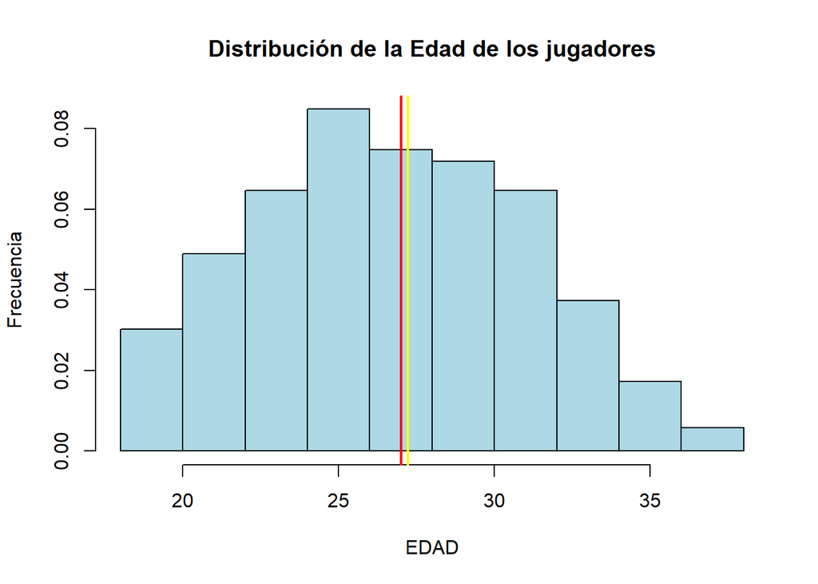

```r
hist(x = LALIGA$EDAD, main = "Distribución de la Edad de los jugadores", xlab = "EDAD", ylab = "Frecuencia", col = "lightblue",prob=TRUE)
abline(v=median(LALIGA$EDAD),col="red",lwd=2)
abline(v=mean(LALIGA$EDAD),col="yellow",lwd=2)
legend(200,0.012,legend = c("Mediana","Media"),lwd=2,col = c("red","yellow"))
```

- Como se observa en la gráfica, la mayoría de jugadores tienen entre 25 a 30 años de edad, es decir, que los equipos de LaLIGA Santander de España realizan a jugadores ya experimentados, asimismo, podemos observar que hay pocos jugadores con una edad mayor a 35 años.

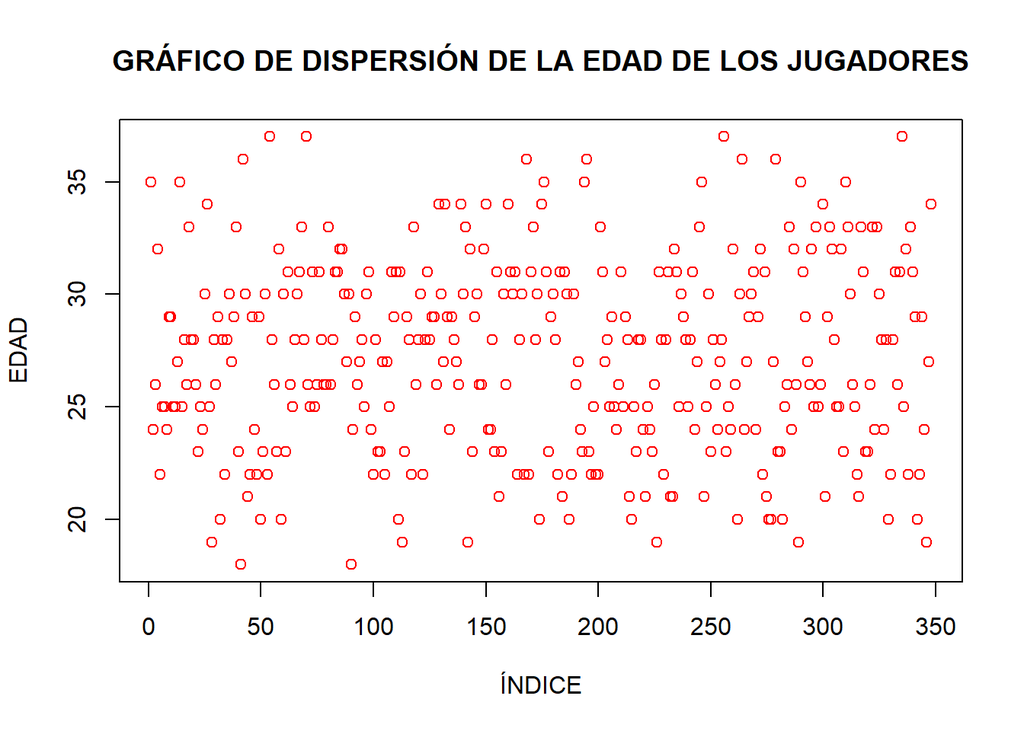

```r
plot(LALIGA$EDAD,main = "GRÁFICO DE DISPERSIÓN DE LA EDAD DE LOS JUGADORES",
     xlab = "ÍNDICE", ylab = "EDAD",
     col = c("red"))
```

-En la gráfica de dispersión de EDAD se pueden visualizar que la dispersión es relativamente, porque los puntos no se encuentran concentrados en un mismo lugar, sino está disperso en todo el gráfico, y tiene sentido porque los jugadores tienen diferentes edades.

#### Histograma de cantidad de Disparos efectivos al arco

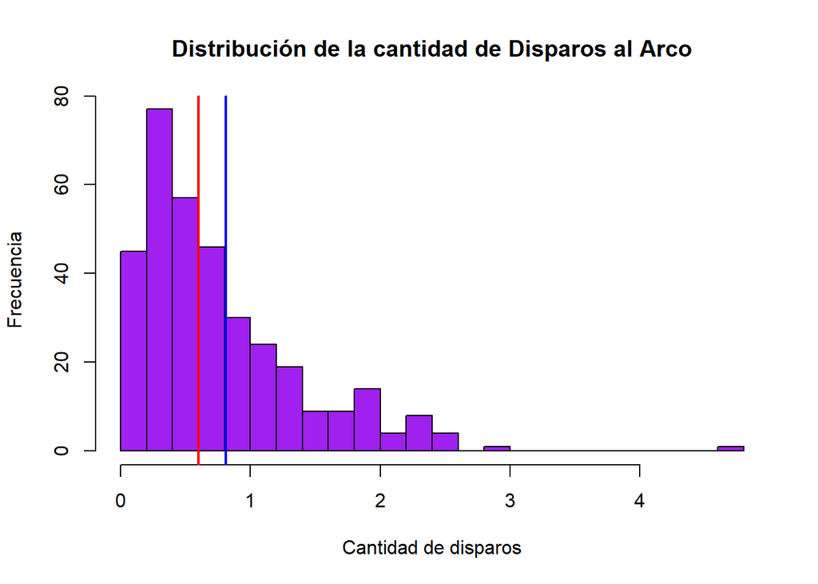

```r
hist(LALIGA$DISPAROS,breaks = 20,main="Distribución de la cantidad de Disparos al Arco",col = "purple", xlab = "Cantidad de disparos",ylab = "Frecuencia")
abline(v=median(LALIGA$DISPAROS),col="red",lwd=2)
abline(v=mean(LALIGA$DISPAROS),col="blue",lwd=2)
legend(200,0.012,legend = c("Mediana","Media"),lwd=2,col = c("red","blue"))
```

- Como podemos observar en la siguiente gráfica obtenemos una mayor cantidad de frecuencia de jugadores, que realizaron un disparo en un rango de [0,1]. Esta gráfica, nos da a a comprender que la tendencia de disparos se encuentra dentro del rango establecido previamente.De esta, manera podemos concluir que la gran mayoría de los jugadores tienen una cantidad de disparos entre 0 y 1, además son muy pocos los que tuvieron una efectividad de disparo al arco alta.

#### Gráfica de dispersión de EDAD VS DISPAROS(Disparos al arco)

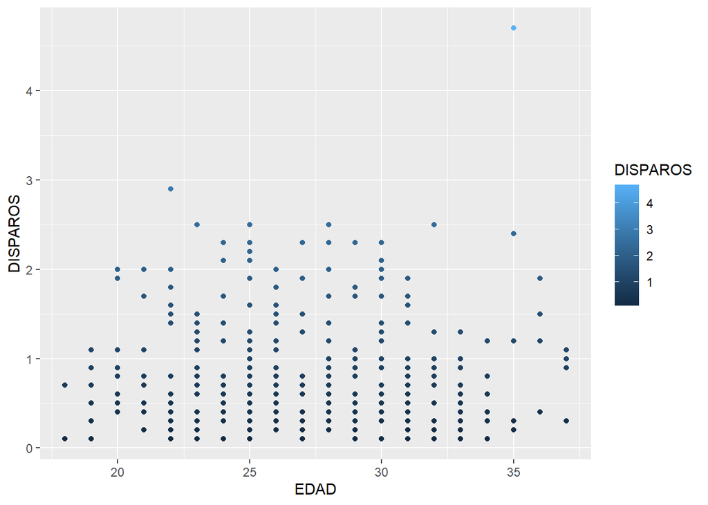

```r
LALIGA %>% ggplot(., aes(EDAD, DISPAROS, colour=DISPAROS)) + geom_point()
```

- La gráfica nos resume la cantidad de disparos en un rango de efectividad de 1 a 5 que hizo un jugador en toda la temporada de la liga, es decir, nos muestra la cantidad de disparos de un jugador que fueron efectivos en el arco(importantes) y cual es su edad, donde nos podemos dar cuenta que la edad no influye en la cantidad de disparos que haga un jugador, porque hay un jugador de 35 años que tuvo una efectividad en el disparo de más de 4 a diferencia de otros.

Con el análisis previo procedemos a filtrar al jugador con la mayor cantidad de disparos efectivos al arco

```r
filter(LALIGA,LALIGA$EDAD>34 & LALIGA$DISPAROS>4)
```

| NOMBRE | EQUIPO | EDAD | POSICION | MINUTOS | AMARILLA | DISPAROS | PASES_A | AEREOS_G | CLASIFICACION | DEFENSA | MEDIO | DELANTERO | DEFENSAD | DEFENSAI | DEFENSAC | MEDIOI | MEDIOD | MEDIOC | PARTIDO | APARICIONES |
| --- | --- | --- | --- | --- | --- | --- | --- | --- | --- | --- | --- | --- | --- | --- | --- | --- | --- | --- | --- | --- |
| Karim Benzema | Real Madrid | 35 | FW | 1306 | 1 | 4.7 | 87 | 0.7 | 7.45 | FALSE | FALSE | TRUE | FALSE | FALSE | FALSE | FALSE | FALSE | FALSE | 15 | 15 |

Como se observa el jugador que más disparos hizo en toda la temporada fue Karim Benzema, quien tiene 35 años, y un número de disparos de efectividad de 4.7 en un rango de 1 a 5, además, este se desempeña como Delantero y pertenece al Real Madrid, es decir, la edad no influye en la cantidad de disparos al arco por un jugador.

#### Analizando la variable APARICIONES

```r
summary(LALIGA$APARICIONES) # detalles de la variable APARICIONES
```

```
##    Min. 1st Qu.  Median    Mean 3rd Qu.    Max.
##    0.00    2.00    5.00    7.25    9.25   25.00
```

```r
unique(LALIGA$APARICIONES) # Se visualiza la variable APARICIONES sin repeticiones.
```

```
##  [1] 15  0  3 23  6 25  4  5 19  2  1 10 22  7 20  9  8 12 24 11 17 14 21 13 16
```

```r
LALIGA %>% count(APARICIONES) # Se visualiza la variable
```

| APARICIONES | n |
| --- | --- |
| 0 | 3 |
| 1 | 42 |
| 2 | 50 |
| 3 | 33 |
| 4 | 26 |
| 5 | 26 |
| 6 | 26 |
| 7 | 23 |
| 8 | 12 |
| 9 | 20 |

[output cut: 15 more lines]

```r
var(LALIGA$APARICIONES,na.rm=T)
```

```
## [1] 41.85375
```

```r
sd(LALIGA$APARICIONES,na.rm=T)  # Desviación estandar
```

```
## [1] 6.469447
```

```r
CV_APAR<-(sd(LALIGA$APARICIONES,na.rm=T)/mean(LALIGA$APARICIONES,na.rm=T))*100   # coeficiente de variación.
CV_APAR
```

```
## [1] 89.23375
```

#### Analizando la variable MINUTOS

```r
summary(LALIGA$MINUTOS) # detalles de la variable APARICIONES
```

```
##    Min. 1st Qu.  Median    Mean 3rd Qu.    Max.
##    14.0   681.5  1101.5  1126.5  1563.5  2239.0
```

```r
unique(LALIGA$MINUTOS) # Se visualiza la variable APARICIONES sin repeticiones.
```

```
##   [1] 1306 1960 1607 1909 1546 2148 1108  433  543 2225 1693 2190 1636 2108 1668
##  [16] 2170 1275 2209 1940 1923 1837 1252 1082 1393 1034 1563 1846 1574 1341 1176
##  [31] 1860 1440 1708 1873 1720 1326 1600 1942 1002 1985 1632  383 1935 1603  538
##  [46] 1350 1033  911 1420 1916 1394 1614 1582 1339  212 1980 2056  447 1267 1296
##  [61] 1534 1702 1081  651 1372 1467 1941 1070 2030 1239  950 1438 2160  805  869
##  [76] 1784 2070 1238 1805 1240  990 1496 1565 1692 2234  366  948 2051 1416 1482
##  [91]  680 1585 1619 1185 1644 1683  702  882 2239 1134  577  423 1144 1537  970
## [106] 1874 1481 1875 1670  542 1095 1922 1309  885 1057  960 1777 1834 2043 1645
## [121] 1735 1689 1500  894 1610 1547 1255 1737 1660  884  983 1459 1470  861  421
## [136] 1677  340  194 1509  531 1555  674 1387 1840 1286  355  490 1293 1191  585
## [151] 1791 1366  803 1263 1581 1119 1910 1118  688 1389  662 2106 1466  682 1052
## [166] 1148  257 1205  694 1682  215 1829 1165 2183  924  925  269 1112  958 1759
## [181] 1473 1435 1159  957 1129  814 1012 1241  583 1247 1899  831  916 2118  708
## [196] 1037 1288 1264 1111 2055 1277 1031  403 1638  779 1227  640 1206 2015 1700
## [211]  559  987  664  345 1583  949  767  661 1301  855  796  838  656  568  270
## [226] 2078  133 1018  746  703 1228  954  525  650 1532 1145 1027  588  875 1354
## [241] 1295  852 1283 1478 1039  742  689 1637  589  754  848 1365 1015 1530  878
## [256]  529 1235  370 1089  696  145  272 1584  374  282 1418  558  487  666  797
## [271] 1019  793  406  444  815  737  986  582  623  342  308  608  222  205  280
## [286]  387  984  317  846 1061  427 1091  367  501  932  895  320  956  353  607
## [301]  791 1480  400  206  333  232  824  686  296  497  647  657  377  462  544
## [316]   87  142   51   14   81   43
```

```r
LALIGA %>% count(MINUTOS) # Se visualiza la variable
```

| MINUTOS | n |
| --- | --- |
| 14 | 1 |
| 43 | 1 |
| 51 | 1 |
| 81 | 1 |
| 87 | 1 |
| 133 | 1 |
| 142 | 1 |
| 145 | 1 |
| 194 | 1 |
| 205 | 1 |

[output cut: 311 more lines]

```r
var(LALIGA$MINUTOS,na.rm=T) # Variación
```

```
## [1] 304096.8
```

```r
sd(LALIGA$MINUTOS,na.rm=T)  # Desviación estándar
```

```
## [1] 551.4498
```

```r
CV_MIN<-(sd(LALIGA$MINUTOS,na.rm=T)/mean(LALIGA$MINUTOS,na.rm=T))*100 # coeficiente de variación.
CV_MIN
```

```
## [1] 48.95211
```